# Reproducible Research: Peer Assessment 1

## Loading and preprocessing the data

I read directly from zip file into dataframe.

Variable “date” is transformed from factor type variable to date type.

## What is mean total number of steps taken per day?

With help of dplyr package I group data by days and calculate sum of total number of steps taken per each day.  
Here’s how looks first 10 days.

```
## Source: local data frame [10 x 2]
##
##          date steps_per_day
##        (date)         (int)
## 1  2012-10-01            NA
## 2  2012-10-02           126
## 3  2012-10-03         11352
## 4  2012-10-04         12116
## 5  2012-10-05         13294
## 6  2012-10-06         15420
## 7  2012-10-07         11015
## 8  2012-10-08            NA
## 9  2012-10-09         12811
## 10 2012-10-10          9900
```

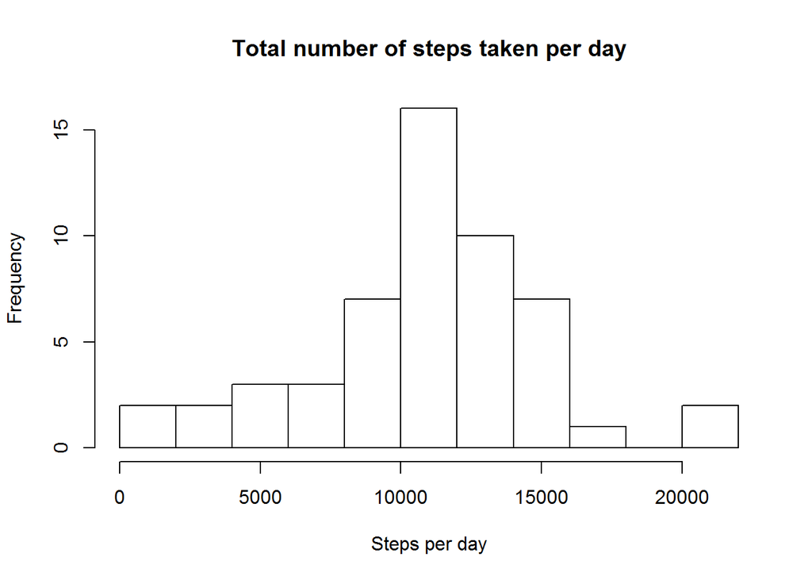

Mean total number of steps taken per day is **10766.19**.  
Median of total number of steps taken per day is **10765.00**.

## What is the average daily activity pattern?

We now group data by 5 minutes intervals and calculate average number od steps for each interval. Plot of data shows average daily activity.

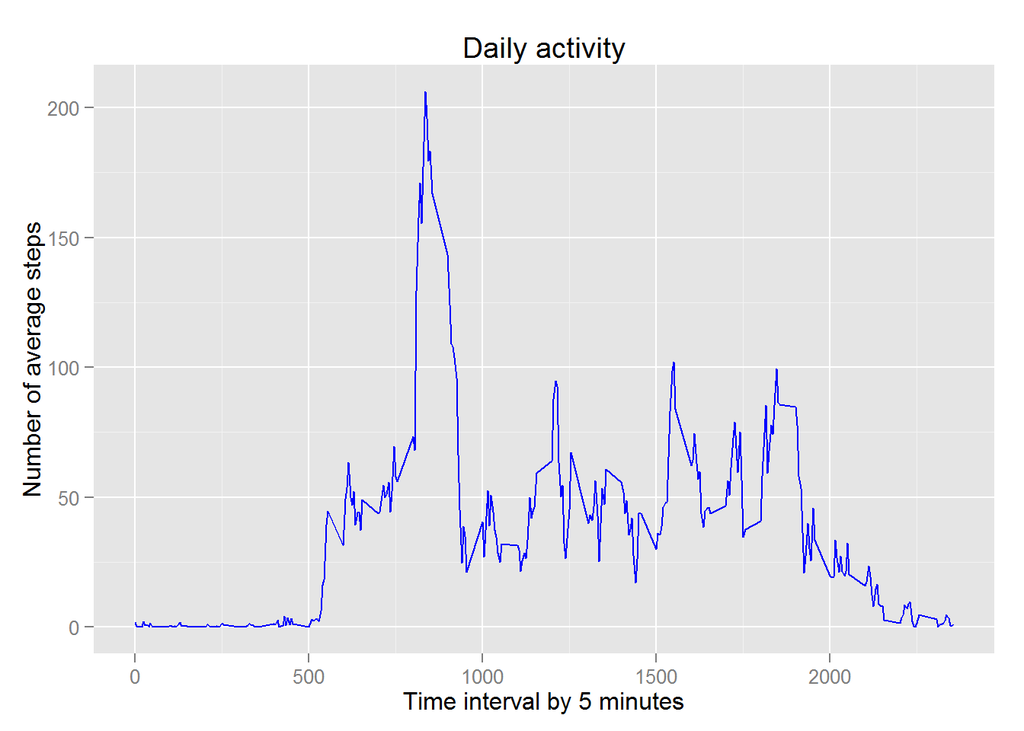

## Imputing missing values

There are missing values in dataset. There are **2304** rows that have “steps” value missing.

I will populate new dataframe with original data and replace missing values with 5-minute average data of days that have value.

Here’s histogram of new dataframe with missing values updated.

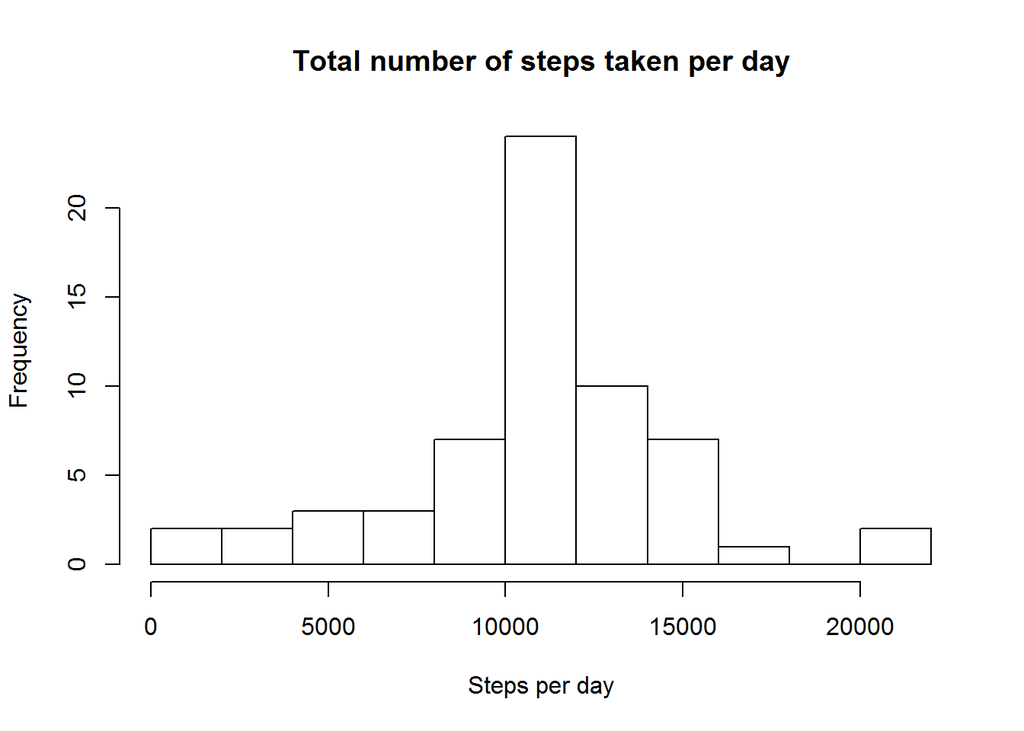

New mean total number of steps taken per day is **10766.19**.  
New median of total number of steps taken per day is **10766.19**.

Mean of new data is same as for original data, but median has changed and now is equal to mean. New data is more centered atound mean.

## Are there differences in activity patterns between weekdays and weekends?

We want to check for weekday/weekend activity pattern differences. For that purpose we create new categorical variable in dataset that categorizes date into “weekend/weekday”.

```
##  Factor w/ 2 levels "weekend","weekday": 2 2 2 2 2 2 2 2 2 2 ...
```

Now we group data and compare activities by 5-minute intervals as average steps.

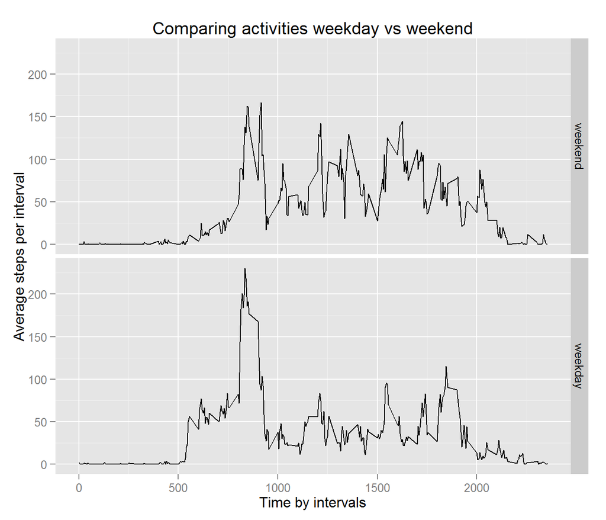